# Data 622 Homework 4: Mental Health Data Modeling

```r
library(knitr)
library(tidyverse)
```

```r
library(caret) # For createDataPartition, featureplot, classification report
library(skimr)    # Used for EDA
#library(corrplot) # For correlation matrix
library(mice) # Multivariate Imputation By Chained Equations
library(micemd)
library(parallel)
library(doParallel)
#library(plyr)
library(VIM)
library(ggplot2)
library(kableExtra)
library(stats)
library(tidymodels)
library(e1071)
library(vcd)

library(ggplot2)
library(Hmisc)
library(Boruta)
library(GGally)
## Global options
# ---------------------------------

options(max.print="108")
opts_knit$set(width=31)
```

# **Loading data**

```r
# getwd()
setwd("~/Data 622/repos/data622_fa2021/hw4")
adhd_data <- readxl::read_excel('ADHD_data.xlsx', sheet = "Data", .name_repair = "universal", na = "")
```

```
## * `ADHD Q1` -> ADHD.Q1
## * `ADHD Q2` -> ADHD.Q2
## * `ADHD Q3` -> ADHD.Q3
## * `ADHD Q4` -> ADHD.Q4
## * `ADHD Q5` -> ADHD.Q5
## * ...
```

```r
# dim(adhd_data)
str(adhd_data)
```

```
## tibble [175 × 54] (S3: tbl_df/tbl/data.frame)
##  $ Initial           : chr [1:175] "JA" "LA" "MD" "RD" ...
##  $ Age               : num [1:175] 24 48 51 43 34 39 41 48 44 27 ...
##  $ Sex               : num [1:175] 1 2 2 1 1 2 2 1 2 2 ...
##  $ Race              : num [1:175] 1 1 1 1 1 1 1 1 1 1 ...
##  $ ADHD.Q1           : num [1:175] 1 3 2 3 4 2 2 2 3 2 ...
##  $ ADHD.Q2           : num [1:175] 1 3 1 3 4 3 2 4 3 3 ...
##  $ ADHD.Q3           : num [1:175] 4 4 2 2 2 1 1 3 3 4 ...
##  $ ADHD.Q4           : num [1:175] 2 4 1 2 4 4 3 4 4 4 ...
##  $ ADHD.Q5           : num [1:175] 3 5 3 4 4 3 4 3 4 4 ...
##  $ ADHD.Q6           : num [1:175] 1 2 3 3 2 2 4 3 3 3 ...
##  $ ADHD.Q7           : num [1:175] 1 2 3 2 3 3 2 1 3 4 ...
##  $ ADHD.Q8           : num [1:175] 3 3 2 4 4 4 3 1 4 3 ...
##  $ ADHD.Q9           : num [1:175] 2 2 0 4 4 4 3 4 3 2 ...
##  $ ADHD.Q10          : num [1:175] 4 4 1 2 2 2 4 2 4 4 ...
```

[output cut: 40 more lines]

```r
# loan_raw <- read.csv('https://raw.githubusercontent.com/metis-macys-66898/data622_fa2021/main/hw3/data/Loan_approval.csv', header = TRUE, na.strings = " ")
# loan_raw[loan_raw==""] <- NA
# loan_raw <- loan_raw %>% mutate_if(is.character, factor)
# loan <- loan_raw
```

## Data Processing Steps

I employed a couple strategies into transforming the data before we can apply models.

- Imputing only when necessary. Imputing by applying the right method for the right variable type.
- Make sure to make the fields into factors when they are categorical variables.

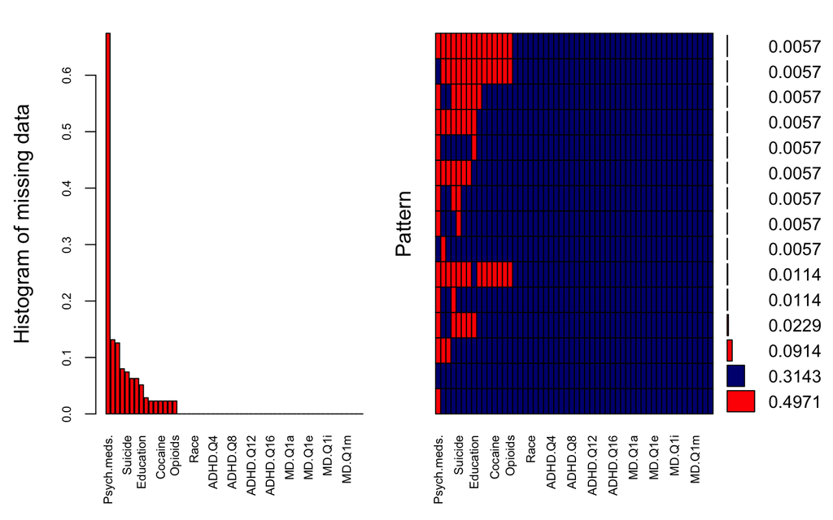

```
##
##  Variables sorted by number of missings:
##            Variable      Count
##         Psych.meds. 0.67428571
##            Subst.Dx 0.13142857
##        Non.subst.Dx 0.12571429
##               Abuse 0.08000000
##             Suicide 0.07428571
##      Hx.of.Violence 0.06285714
##  Disorderly.Conduct 0.06285714
##           Education 0.05142857
##         Court.order 0.02857143
##             Alcohol 0.02285714
##                 THC 0.02285714
##             Cocaine 0.02285714
##          Stimulants 0.02285714
##  Sedative.hypnotics 0.02285714
##             Opioids 0.02285714
##             Initial 0.00000000
##                 Age 0.00000000
##                 Sex 0.00000000
##                Race 0.00000000
##             ADHD.Q1 0.00000000
##             ADHD.Q2 0.00000000
##             ADHD.Q3 0.00000000
##             ADHD.Q4 0.00000000
##             ADHD.Q5 0.00000000
##             ADHD.Q6 0.00000000
##             ADHD.Q7 0.00000000
##             ADHD.Q8 0.00000000
##             ADHD.Q9 0.00000000
##            ADHD.Q10 0.00000000
##            ADHD.Q11 0.00000000
##            ADHD.Q12 0.00000000
##            ADHD.Q13 0.00000000
##            ADHD.Q14 0.00000000
##            ADHD.Q15 0.00000000
##            ADHD.Q16 0.00000000
##            ADHD.Q17 0.00000000
##            ADHD.Q18 0.00000000
##          ADHD.Total 0.00000000
##              MD.Q1a 0.00000000
##              MD.Q1b 0.00000000
##              MD.Q1c 0.00000000
##              MD.Q1d 0.00000000
##              MD.Q1e 0.00000000
##              MD.Q1f 0.00000000
##              MD.Q1g 0.00000000
##              MD.Q1h 0.00000000
##              MD.Q1i 0.00000000
##              MD.Q1j 0.00000000
##              MD.Q1k 0.00000000
##              MD.Q1L 0.00000000
##              MD.Q1m 0.00000000
##               MD.Q2 0.00000000
##               MD.Q3 0.00000000
##            MD.TOTAL 0.00000000
```

```r
aggr_plot <- aggr(adhd_data, col=c('navyblue','red'), numbers=TRUE, sortVars=TRUE, labels=names(data), cex.axis=.7, gap=3, ylab=c("Histogram of missing data","Pattern"))
```

Removing Initial as it provides no values to any models. Also, I removed Psych.meds. as it has 67% missing.

```r
adhd_data_pre_imp <- adhd_data %>% select(-c('Initial','Psych.meds.'))
skim(adhd_data_pre_imp) %>% dplyr::filter( n_missing > 0 )
```

Data summary

| Name | adhd_data_pre_imp |
| --- | --- |
| Number of rows | 175 |
| Number of columns | 52 |
| _______________________ |  |
| Column type frequency: |  |
| numeric | 14 |
| ________________________ |  |
| Group variables | None |

**Variable type: numeric**

| skim_variable | n_missing | complete_rate | mean | sd | p0 | p25 | p50 | p75 | p100 | hist |
| --- | --- | --- | --- | --- | --- | --- | --- | --- | --- | --- |
| Alcohol | 4 | 0.98 | 1.35 | 1.39 | 0 | 0 | 1 | 3.0 | 3 | ▇▂▁▁▆ |
| THC | 4 | 0.98 | 0.81 | 1.27 | 0 | 0 | 0 | 1.5 | 3 | ▇▁▁▁▃ |
| Cocaine | 4 | 0.98 | 1.09 | 1.39 | 0 | 0 | 0 | 3.0 | 3 | ▇▁▁▁▅ |
| Stimulants | 4 | 0.98 | 0.12 | 0.53 | 0 | 0 | 0 | 0.0 | 3 | ▇▁▁▁▁ |
| Sedative.hypnotics | 4 | 0.98 | 0.12 | 0.54 | 0 | 0 | 0 | 0.0 | 3 | ▇▁▁▁▁ |
| Opioids | 4 | 0.98 | 0.39 | 0.99 | 0 | 0 | 0 | 0.0 | 3 | ▇▁▁▁▁ |
| Court.order | 5 | 0.97 | 0.09 | 0.28 | 0 | 0 | 0 | 0.0 | 1 | ▇▁▁▁▁ |
| Education | 9 | 0.95 | 11.90 | 2.17 | 6 | 11 | 12 | 13.0 | 19 | ▁▅▇▂▁ |
| Hx.of.Violence | 11 | 0.94 | 0.24 | 0.43 | 0 | 0 | 0 | 0.0 | 1 | ▇▁▁▁▂ |
| Disorderly.Conduct | 11 | 0.94 | 0.73 | 0.45 | 0 | 0 | 1 | 1.0 | 1 | ▃▁▁▁▇ |
| Suicide | 13 | 0.93 | 0.30 | 0.46 | 0 | 0 | 0 | 1.0 | 1 | ▇▁▁▁▃ |
| Abuse | 14 | 0.92 | 1.33 | 2.12 | 0 | 0 | 0 | 2.0 | 7 | ▇▂▁▁▁ |
| Non.subst.Dx | 22 | 0.87 | 0.44 | 0.68 | 0 | 0 | 0 | 1.0 | 2 | ▇▁▃▁▁ |
| Subst.Dx | 23 | 0.87 | 1.14 | 0.93 | 0 | 0 | 1 | 2.0 | 3 | ▆▇▁▅▂ |

```r
adhd_data_pre_imp <- adhd_data_pre_imp %>% mutate(NonSubstDx =  as.factor(Non.subst.Dx)  ,
                                                  SubstDx = as.factor(Subst.Dx) ,
                                                  Abuse = factor(Abuse, ordered = TRUE),
                                                  Alcohol = as.factor(Alcohol)
)


adhd_data_pre_imp <- adhd_data_pre_imp %>%  mutate_if(is.numeric, factor)
skim(adhd_data_pre_imp)
```

Data summary

| Name | adhd_data_pre_imp |
| --- | --- |
| Number of rows | 175 |
| Number of columns | 54 |
| _______________________ |  |
| Column type frequency: |  |
| factor | 54 |
| ________________________ |  |
| Group variables | None |

**Variable type: factor**

| skim_variable | n_missing | complete_rate | ordered | n_unique | top_counts |
| --- | --- | --- | --- | --- | --- |
| Age | 0 | 1.00 | FALSE | 42 | 44: 12, 51: 9, 26: 8, 33: 7 |
| Sex | 0 | 1.00 | FALSE | 2 | 1: 99, 2: 76 |
| Race | 0 | 1.00 | FALSE | 4 | 2: 100, 1: 72, 6: 2, 3: 1 |
| ADHD.Q1 | 0 | 1.00 | FALSE | 5 | 2: 44, 1: 43, 0: 39, 3: 30 |
| ADHD.Q2 | 0 | 1.00 | FALSE | 5 | 2: 47, 1: 46, 3: 33, 0: 25 |
| ADHD.Q3 | 0 | 1.00 | FALSE | 5 | 1: 46, 2: 46, 3: 32, 0: 26 |
| ADHD.Q4 | 0 | 1.00 | FALSE | 5 | 2: 50, 4: 36, 1: 31, 3: 31 |
| ADHD.Q5 | 0 | 1.00 | FALSE | 6 | 3: 47, 4: 41, 0: 33, 2: 32 |
| ADHD.Q6 | 0 | 1.00 | FALSE | 5 | 2: 45, 3: 45, 0: 36, 1: 29 |
| ADHD.Q7 | 0 | 1.00 | FALSE | 5 | 2: 54, 1: 53, 3: 25, 0: 22 |
| ADHD.Q8 | 0 | 1.00 | FALSE | 5 | 3: 42, 1: 40, 2: 40, 4: 32 |
| ADHD.Q9 | 0 | 1.00 | FALSE | 5 | 1: 43, 3: 41, 2: 36, 0: 31 |
| ADHD.Q10 | 0 | 1.00 | FALSE | 5 | 2: 49, 1: 46, 3: 33, 4: 32 |
| ADHD.Q11 | 0 | 1.00 | FALSE | 5 | 2: 48, 3: 43, 4: 35, 1: 33 |
| ADHD.Q12 | 0 | 1.00 | FALSE | 5 | 0: 55, 1: 55, 2: 37, 3: 15 |
| ADHD.Q13 | 0 | 1.00 | FALSE | 5 | 3: 47, 2: 46, 4: 38, 1: 29 |
| ADHD.Q14 | 0 | 1.00 | FALSE | 5 | 3: 47, 2: 40, 4: 37, 0: 27 |
| ADHD.Q15 | 0 | 1.00 | FALSE | 5 | 0: 50, 1: 39, 2: 35, 3: 27 |
| ADHD.Q16 | 0 | 1.00 | FALSE | 5 | 1: 49, 0: 40, 2: 39, 4: 30 |
| ADHD.Q17 | 0 | 1.00 | FALSE | 5 | 0: 49, 2: 46, 1: 41, 3: 22 |
| ADHD.Q18 | 0 | 1.00 | FALSE | 5 | 1: 52, 0: 49, 2: 35, 3: 20 |
| ADHD.Total | 0 | 1.00 | FALSE | 62 | 17: 8, 31: 7, 32: 7, 24: 6 |
| MD.Q1a | 0 | 1.00 | FALSE | 2 | 1: 96, 0: 79 |
| MD.Q1b | 0 | 1.00 | FALSE | 2 | 1: 100, 0: 75 |
| MD.Q1c | 0 | 1.00 | FALSE | 2 | 1: 95, 0: 80 |
| MD.Q1d | 0 | 1.00 | FALSE | 2 | 1: 102, 0: 73 |
| MD.Q1e | 0 | 1.00 | FALSE | 2 | 1: 97, 0: 78 |
| MD.Q1f | 0 | 1.00 | FALSE | 2 | 1: 122, 0: 53 |
| MD.Q1g | 0 | 1.00 | FALSE | 2 | 1: 126, 0: 49 |
| MD.Q1h | 0 | 1.00 | FALSE | 2 | 1: 98, 0: 77 |
| MD.Q1i | 0 | 1.00 | FALSE | 2 | 1: 103, 0: 72 |
| MD.Q1j | 0 | 1.00 | FALSE | 2 | 0: 107, 1: 68 |
| MD.Q1k | 0 | 1.00 | FALSE | 2 | 0: 90, 1: 85 |
| MD.Q1L | 0 | 1.00 | FALSE | 2 | 1: 102, 0: 73 |
| MD.Q1m | 0 | 1.00 | FALSE | 2 | 0: 89, 1: 86 |
| MD.Q2 | 0 | 1.00 | FALSE | 2 | 1: 126, 0: 49 |
| MD.Q3 | 0 | 1.00 | FALSE | 4 | 3: 76, 2: 49, 0: 25, 1: 25 |
| MD.TOTAL | 0 | 1.00 | FALSE | 18 | 11: 18, 15: 14, 10: 13, 13: 13 |
| Alcohol | 4 | 0.98 | FALSE | 4 | 0: 80, 3: 66, 1: 18, 2: 7 |
| THC | 4 | 0.98 | FALSE | 4 | 0: 116, 3: 40, 1: 12, 2: 3 |
| Cocaine | 4 | 0.98 | FALSE | 4 | 0: 101, 3: 56, 1: 9, 2: 5 |
| Stimulants | 4 | 0.98 | FALSE | 3 | 0: 160, 1: 6, 3: 5 |
| Sedative.hypnotics | 4 | 0.98 | FALSE | 4 | 0: 161, 3: 5, 1: 4, 2: 1 |
| Opioids | 4 | 0.98 | FALSE | 3 | 0: 146, 3: 21, 1: 4 |
| Court.order | 5 | 0.97 | FALSE | 2 | 0: 155, 1: 15 |
| Education | 9 | 0.95 | FALSE | 14 | 12: 67, 11: 23, 13: 15, 14: 14 |
| Hx.of.Violence | 11 | 0.94 | FALSE | 2 | 0: 124, 1: 40 |
| Disorderly.Conduct | 11 | 0.94 | FALSE | 2 | 1: 119, 0: 45 |
| Suicide | 13 | 0.93 | FALSE | 2 | 0: 113, 1: 49 |
| Abuse | 14 | 0.92 | TRUE | 8 | 0: 101, 2: 20, 5: 10, 1: 8 |
| Non.subst.Dx | 22 | 0.87 | FALSE | 3 | 0: 102, 1: 35, 2: 16 |
| Subst.Dx | 23 | 0.87 | FALSE | 4 | 1: 61, 0: 42, 2: 35, 3: 14 |
| NonSubstDx | 22 | 0.87 | FALSE | 3 | 0: 102, 1: 35, 2: 16 |
| SubstDx | 23 | 0.87 | FALSE | 4 | 1: 61, 0: 42, 2: 35, 3: 14 |

```r
adhd_data_pre_imp1 <- adhd_data_pre_imp %>% mutate(Education = as.numeric(Education)  )
skim(adhd_data_pre_imp1)
```

Data summary

| Name | adhd_data_pre_imp1 |
| --- | --- |
| Number of rows | 175 |
| Number of columns | 54 |
| _______________________ |  |
| Column type frequency: |  |
| factor | 53 |
| numeric | 1 |
| ________________________ |  |
| Group variables | None |

**Variable type: factor**

| skim_variable | n_missing | complete_rate | ordered | n_unique | top_counts |
| --- | --- | --- | --- | --- | --- |
| Age | 0 | 1.00 | FALSE | 42 | 44: 12, 51: 9, 26: 8, 33: 7 |
| Sex | 0 | 1.00 | FALSE | 2 | 1: 99, 2: 76 |
| Race | 0 | 1.00 | FALSE | 4 | 2: 100, 1: 72, 6: 2, 3: 1 |
| ADHD.Q1 | 0 | 1.00 | FALSE | 5 | 2: 44, 1: 43, 0: 39, 3: 30 |
| ADHD.Q2 | 0 | 1.00 | FALSE | 5 | 2: 47, 1: 46, 3: 33, 0: 25 |
| ADHD.Q3 | 0 | 1.00 | FALSE | 5 | 1: 46, 2: 46, 3: 32, 0: 26 |
| ADHD.Q4 | 0 | 1.00 | FALSE | 5 | 2: 50, 4: 36, 1: 31, 3: 31 |
| ADHD.Q5 | 0 | 1.00 | FALSE | 6 | 3: 47, 4: 41, 0: 33, 2: 32 |
| ADHD.Q6 | 0 | 1.00 | FALSE | 5 | 2: 45, 3: 45, 0: 36, 1: 29 |
| ADHD.Q7 | 0 | 1.00 | FALSE | 5 | 2: 54, 1: 53, 3: 25, 0: 22 |
| ADHD.Q8 | 0 | 1.00 | FALSE | 5 | 3: 42, 1: 40, 2: 40, 4: 32 |
| ADHD.Q9 | 0 | 1.00 | FALSE | 5 | 1: 43, 3: 41, 2: 36, 0: 31 |
| ADHD.Q10 | 0 | 1.00 | FALSE | 5 | 2: 49, 1: 46, 3: 33, 4: 32 |
| ADHD.Q11 | 0 | 1.00 | FALSE | 5 | 2: 48, 3: 43, 4: 35, 1: 33 |
| ADHD.Q12 | 0 | 1.00 | FALSE | 5 | 0: 55, 1: 55, 2: 37, 3: 15 |
| ADHD.Q13 | 0 | 1.00 | FALSE | 5 | 3: 47, 2: 46, 4: 38, 1: 29 |
| ADHD.Q14 | 0 | 1.00 | FALSE | 5 | 3: 47, 2: 40, 4: 37, 0: 27 |
| ADHD.Q15 | 0 | 1.00 | FALSE | 5 | 0: 50, 1: 39, 2: 35, 3: 27 |
| ADHD.Q16 | 0 | 1.00 | FALSE | 5 | 1: 49, 0: 40, 2: 39, 4: 30 |
| ADHD.Q17 | 0 | 1.00 | FALSE | 5 | 0: 49, 2: 46, 1: 41, 3: 22 |
| ADHD.Q18 | 0 | 1.00 | FALSE | 5 | 1: 52, 0: 49, 2: 35, 3: 20 |
| ADHD.Total | 0 | 1.00 | FALSE | 62 | 17: 8, 31: 7, 32: 7, 24: 6 |
| MD.Q1a | 0 | 1.00 | FALSE | 2 | 1: 96, 0: 79 |
| MD.Q1b | 0 | 1.00 | FALSE | 2 | 1: 100, 0: 75 |
| MD.Q1c | 0 | 1.00 | FALSE | 2 | 1: 95, 0: 80 |
| MD.Q1d | 0 | 1.00 | FALSE | 2 | 1: 102, 0: 73 |
| MD.Q1e | 0 | 1.00 | FALSE | 2 | 1: 97, 0: 78 |
| MD.Q1f | 0 | 1.00 | FALSE | 2 | 1: 122, 0: 53 |
| MD.Q1g | 0 | 1.00 | FALSE | 2 | 1: 126, 0: 49 |
| MD.Q1h | 0 | 1.00 | FALSE | 2 | 1: 98, 0: 77 |
| MD.Q1i | 0 | 1.00 | FALSE | 2 | 1: 103, 0: 72 |
| MD.Q1j | 0 | 1.00 | FALSE | 2 | 0: 107, 1: 68 |
| MD.Q1k | 0 | 1.00 | FALSE | 2 | 0: 90, 1: 85 |
| MD.Q1L | 0 | 1.00 | FALSE | 2 | 1: 102, 0: 73 |
| MD.Q1m | 0 | 1.00 | FALSE | 2 | 0: 89, 1: 86 |
| MD.Q2 | 0 | 1.00 | FALSE | 2 | 1: 126, 0: 49 |
| MD.Q3 | 0 | 1.00 | FALSE | 4 | 3: 76, 2: 49, 0: 25, 1: 25 |
| MD.TOTAL | 0 | 1.00 | FALSE | 18 | 11: 18, 15: 14, 10: 13, 13: 13 |
| Alcohol | 4 | 0.98 | FALSE | 4 | 0: 80, 3: 66, 1: 18, 2: 7 |
| THC | 4 | 0.98 | FALSE | 4 | 0: 116, 3: 40, 1: 12, 2: 3 |
| Cocaine | 4 | 0.98 | FALSE | 4 | 0: 101, 3: 56, 1: 9, 2: 5 |
| Stimulants | 4 | 0.98 | FALSE | 3 | 0: 160, 1: 6, 3: 5 |
| Sedative.hypnotics | 4 | 0.98 | FALSE | 4 | 0: 161, 3: 5, 1: 4, 2: 1 |
| Opioids | 4 | 0.98 | FALSE | 3 | 0: 146, 3: 21, 1: 4 |
| Court.order | 5 | 0.97 | FALSE | 2 | 0: 155, 1: 15 |
| Hx.of.Violence | 11 | 0.94 | FALSE | 2 | 0: 124, 1: 40 |
| Disorderly.Conduct | 11 | 0.94 | FALSE | 2 | 1: 119, 0: 45 |
| Suicide | 13 | 0.93 | FALSE | 2 | 0: 113, 1: 49 |
| Abuse | 14 | 0.92 | TRUE | 8 | 0: 101, 2: 20, 5: 10, 1: 8 |
| Non.subst.Dx | 22 | 0.87 | FALSE | 3 | 0: 102, 1: 35, 2: 16 |
| Subst.Dx | 23 | 0.87 | FALSE | 4 | 1: 61, 0: 42, 2: 35, 3: 14 |
| NonSubstDx | 22 | 0.87 | FALSE | 3 | 0: 102, 1: 35, 2: 16 |
| SubstDx | 23 | 0.87 | FALSE | 4 | 1: 61, 0: 42, 2: 35, 3: 14 |

**Variable type: numeric**

| skim_variable | n_missing | complete_rate | mean | sd | p0 | p25 | p50 | p75 | p100 | hist |
| --- | --- | --- | --- | --- | --- | --- | --- | --- | --- | --- |
| Education | 9 | 0.95 | 6.9 | 2.17 | 1 | 6 | 7 | 8 | 14 | ▁▅▇▂▁ |

### Imputation

More specifically, I separated the variables with missing values into the following categories:

- **Categorical Variables with more than 2 levels:** Subst.Dx, NonSubstDx, Opioids, Sedative.hypnotics, Stimulants, Cocaine, THC, Alcohol - polyreg
- **Categorical Variables with 2 levels:** Disorderly.Conduct, Hx.of.Violence, Court.order - logreg
- **Discrete variable (ordered) with more than 2 levels:** Abuse - polr
- **Continuous Variables:** Education **- pmm -> norm**

**Note that all the imputation codes below are intentionally commented out just because we relied on saved adhd_data_2.rds and adhd_data_3.rds files as the process of fully paralleled processed mice methods still would take significant amount of time to run (for the RMD knitting). It might take approx. 5 mins to the upwards of 17 mins.**

```r
init <- mice(adhd_data_pre_imp1, maxit=0)
meth <- init$method
predM <- init$predictorMatrix
meth[c('Education')] <- 'pmm'
meth[c('Disorderly.Conduct', 'Hx.of.Violence', 'Court.order')] <- 'logreg'
meth[c('Subst.Dx', 'NonSubstDx' , 'Opioids', 'Sedative.hypnotics', 'Stimulants', 'Cocaine', 'THC', 'Alcohol')] <- 'polyreg'
meth[c('Abuse')] = 'polr'
meth[c('Age','Sex','Race','ADHD.Q1','ADHD.Q2','ADHD.Q3','ADHD.Q4','ADHD.Q5','ADHD.Q6','ADHD.Q7','ADHD.Q8','ADHD.Q9','ADHD.Q10','ADHD.Q11','ADHD.Q12','ADHD.Q13','ADHD.Q14','ADHD.Q15','ADHD.Q16','ADHD.Q17','ADHD.Q18','ADHD.Total','MD.Q1a','MD.Q1b','MD.Q1c','MD.Q1d','MD.Q1e','MD.Q1f','MD.Q1g','MD.Q1h','MD.Q1i','MD.Q1j','MD.Q1k','MD.Q1L','MD.Q1m','MD.Q2','MD.Q3','MD.TOTAL','Suicide')] = ''


# no_cores <- detectCores() - 1
#
# cl<-makePSOCKcluster(no_cores)
#
# registerDoParallel(cl)
#
# start.time<-proc.time()
#
# adhd_data_imp1 <- mice.par(adhd_data_pre_imp1, method=meth, predictorMatrix=predM, seed=301, m = 5)
#
# stop.time<-proc.time()
#
# run.time<-stop.time -start.time
#
# print(run.time)
#
# stopCluster(cl)
# user  system elapsed
#   1.826   4.303 264.775
```

#### Examining the imputations

Examining the imputations for Education. As the 50-th percentile before was 12, we picked an impute that is exactly that. Impute #4 fits the bill.

```r
# str(adhd_data_imp1)
# skim(adhd_data_imp1) %>% dplyr::filter( n_missing > 0 )
#
#Eduation
# adhd_data_imp1$imp$Education
# adhd_data_pre_imp1[140:142,]
#
#
# #Age
# adhd_data_imp1$imp$Alcohol
```

```r
# adhd_data_2 <- complete(adhd_data_imp1, 4) # 2nd argument if not provided is defaulted to 1
```

```r
# skim(adhd_data_2) %>% dplyr::filter( n_missing > 0 )
# # # saving a R data frame

# saveRDS(adhd_data_2, "adhd_data_2.rds")
```

Ended up dropping 29 records as even there are other means of imputing the missing records manually. I just don’t think it’s trustworthy when advanced algorithms did not end up imputing them. The need to have complete cases, except for the suicide variable for section of clustering and PCA where suicide variable is not the response variable, or variable of interest, is the ultimate reason why I had to drop any records with even a missing field from the dataset.

```r
# loading rds object

# adhd_data_2 <- readRDS("adhd_data_2.rds")



# adhd_data_pre_imp1[complete.cases(adhd_data_pre_imp1[ , -49]),]

# saved 3 records
# adhd_data_3 <- adhd_data_2[complete.cases(adhd_data_2[ , -49]),]
```

```r
# Saving the records
# saveRDS(adhd_data_3, "adhd_data_3.rds")
#Loading the records
adhd_data_3 <- readRDS("adhd_data_3.rds")
```

#### Count for each Education / suicide attempt

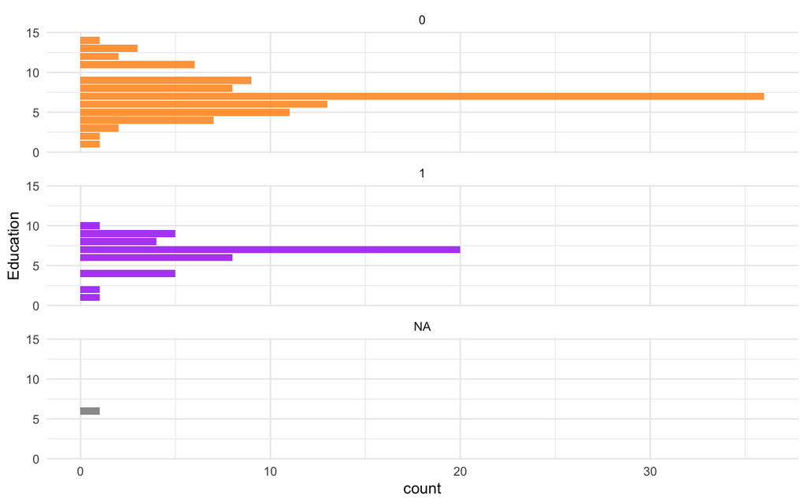

```r
ggplot(adhd_data_3, aes(x = Education, fill = Suicide)) +
  geom_bar(alpha = 0.8) +
  scale_fill_manual(values = c("darkorange", "purple", "cyan4"),
                    guide = F) +
  theme_minimal() +
  facet_wrap(~Suicide, ncol = 1) +
  coord_flip()
```

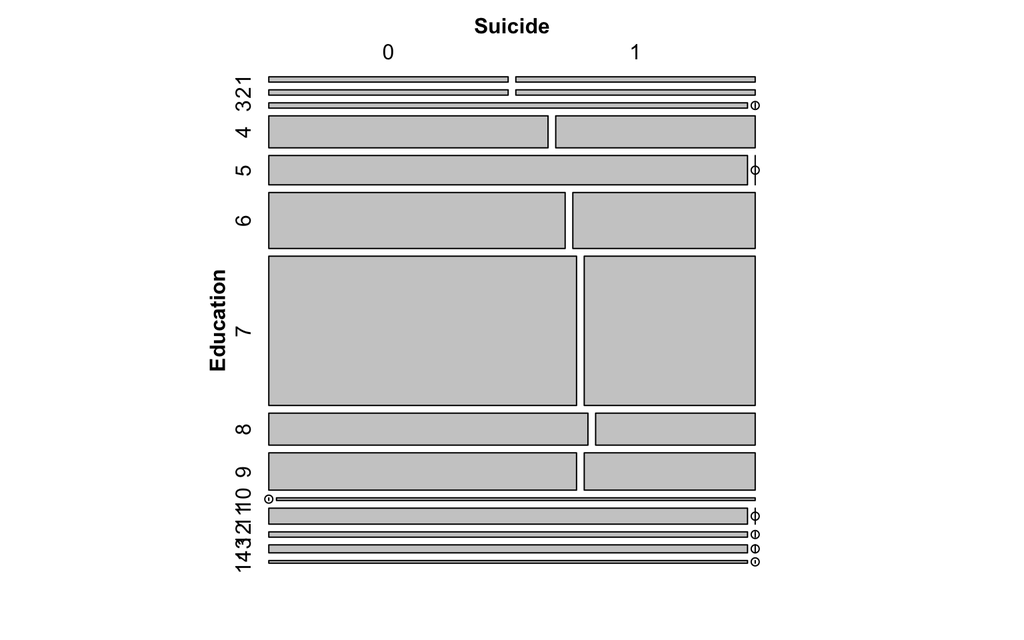

```r
mosaic(~ Education + Suicide, data = adhd_data_3)
```

#### Count for each Subst.Dx / suicide attempt

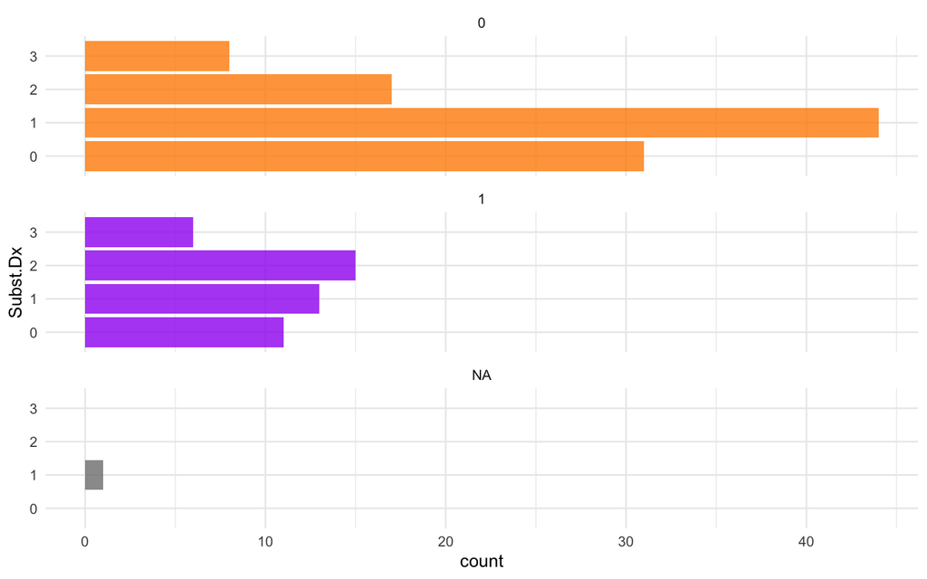

```r
ggplot(adhd_data_3, aes(x = Subst.Dx, fill = Suicide)) +
  geom_bar(alpha = 0.8) +
  scale_fill_manual(values = c("darkorange", "purple", "cyan4"),
                    guide = F) +
  theme_minimal() +
  facet_wrap(~Suicide, ncol = 1) +
  coord_flip()
```

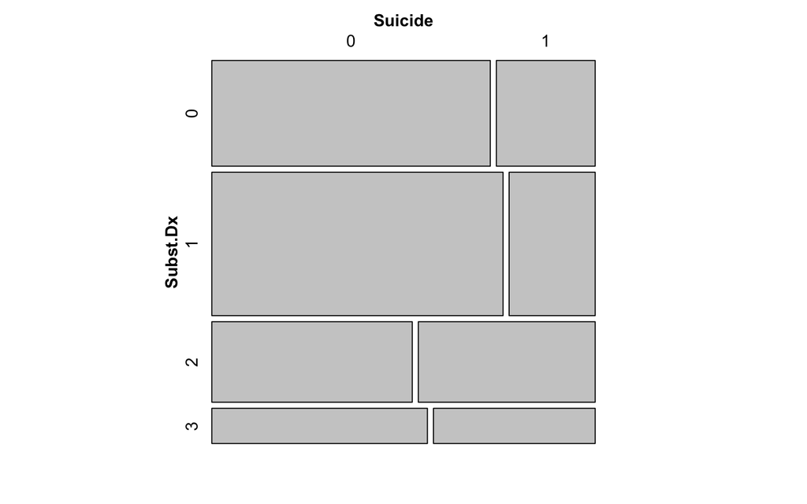

```r
mosaic(~ Subst.Dx + Suicide, data = adhd_data_3)
```

#### Count for each Non.subst.Dx / suicide attempt

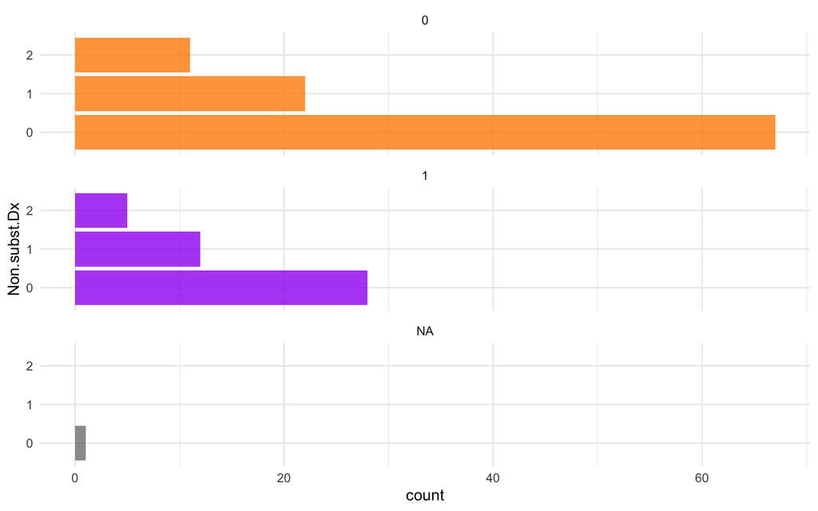

```r
ggplot(adhd_data_3, aes(x = Non.subst.Dx, fill = Suicide)) +
  geom_bar(alpha = 0.8) +
  scale_fill_manual(values = c("darkorange", "purple", "cyan4"),
                    guide = F) +
  theme_minimal() +
  facet_wrap(~Suicide, ncol = 1) +
  coord_flip()
```

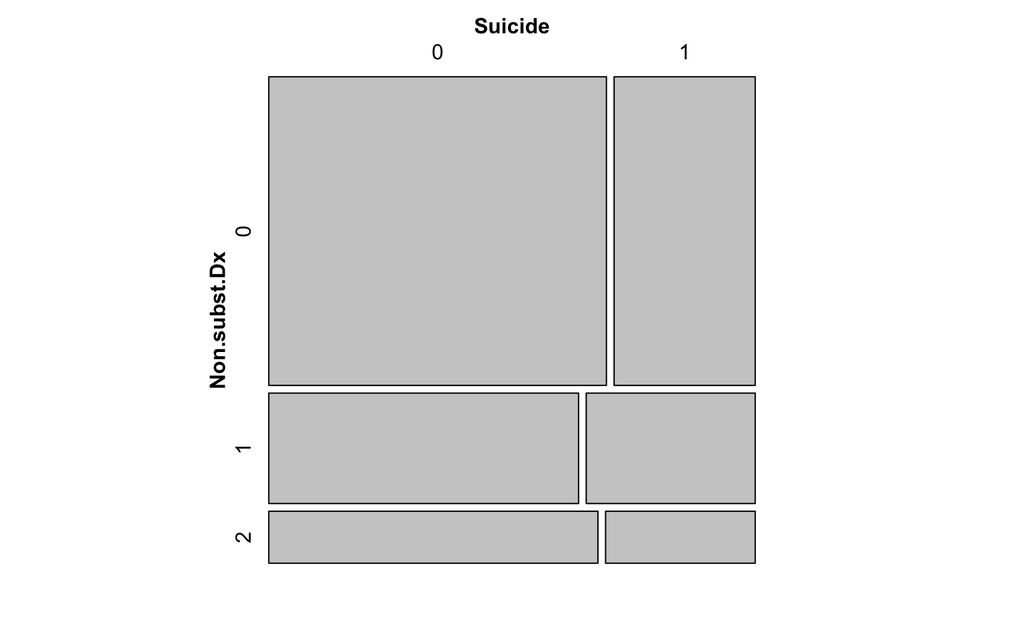

```r
mosaic(~ Non.subst.Dx + Suicide, data = adhd_data_3)
```

#### Count for each Abuse / Suicide

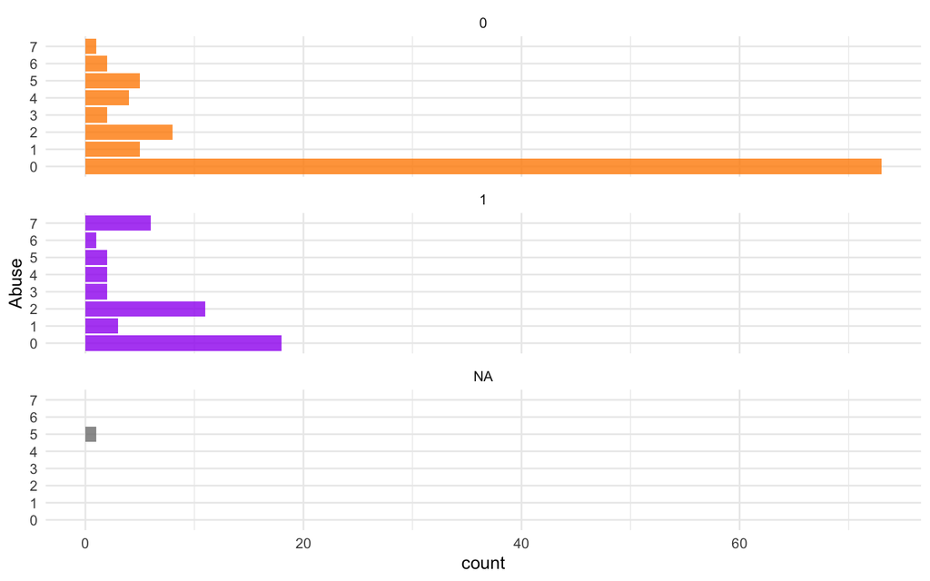

```r
ggplot(adhd_data_3, aes(x = Abuse, fill = Suicide)) +
  geom_bar(alpha = 0.8) +
  scale_fill_manual(values = c("darkorange", "purple", "cyan4", "black"),
                    guide = F) +
  theme_minimal() +
  facet_wrap(~Suicide, ncol = 1) +
  coord_flip()
```

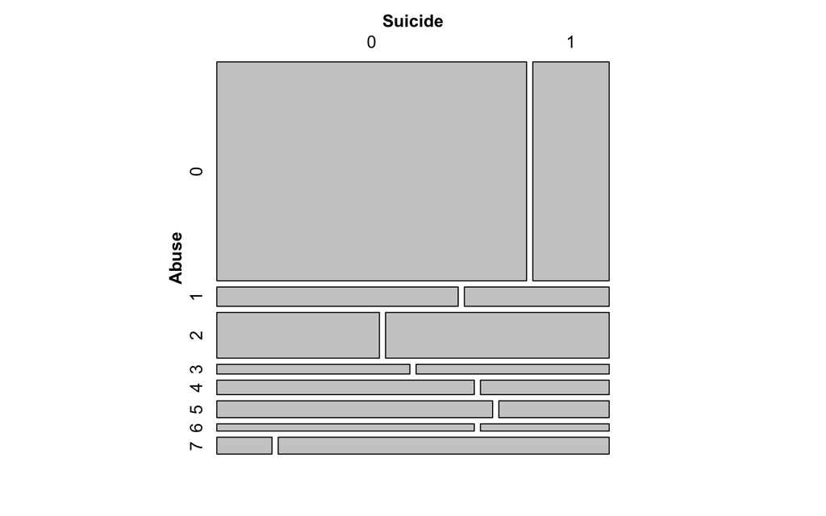

```r
mosaic(~ Abuse + Suicide, data = adhd_data_3)
```

## Clustering Method

Here we are going to start our clustering techniques using hierarchical clustering. The benefits of this clustering type is that we don’t need to specify the number of clusters and results are reproducable.

The output from hierarchical clustering is a dendogram, which is a graph that looks like a tree. We can see from our dendogram below there are 4 distinct clusters.

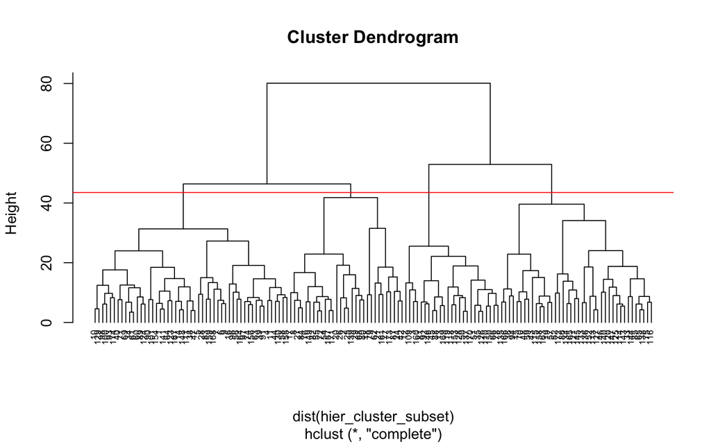

```r
hier_cluster_subset <- adhd_data_3 %>% select(c('Age','Sex','Race','ADHD.Total','MD.TOTAL','Alcohol','THC','Cocaine','Stimulants','Sedative.hypnotics','Opioids','Court.order','Education','Hx.of.Violence','Disorderly.Conduct','Suicide','Abuse','Non.subst.Dx','Subst.Dx','NonSubstDx','SubstDx'))
hier_cluster_complete <- hclust(dist(hier_cluster_subset),method="complete")
plot(hier_cluster_complete, hang = -1, cex = 0.6)
abline(h = 43.5, col = "red")
```

From the above dendogram, we can see there are 4 distinct clusters so we will cut our tree at this level using the function **cutree()**. This function returns a vector of cluster assignments, which can be see here:

```r
vect_cut <- cutree(hier_cluster_complete,4)
hier_cluster_subset$cluster_pred <- vect_cut
vect_cut
```

```
##   1   2   3   4   5   6   7   8   9  10  11  12  13  14  15  16  17  18  19  20
##   1   2   3   1   1   1   1   2   1   1   1   3   3   1   4   1   2   2   4   2
##  21  24  25  26  27  28  29  33  34  35  36  38  39  40  42  43  44  45  46  47
##   2   2   2   2   2   1   2   4   1   3   4   1   1   1   2   4   1   3   4   1
##  48  50  51  52  54  55  56  57  58  59  60  61  62  63  64  65  66  68  69  70
##   4   3   3   4   2   2   1   4   1   4   1   1   2   1   1   4   3   2   1   4
##  71  72  74  75  76  77  78  79  80  81  82  83  84  85  86  87  88  89  90  91
##   1   2   1   4   2   2   3   2   2   3   2   1   2   4   4   2   3   1   1   1
##  92  93  94  96  97  98 100 101 109 110 111 113 114 115 116 118 119 120 121 123
##   3   1   4   1   1   1   1   1   3   3   1   4   4   4   4   3   3   4   4   1
## 124 125 126 127 128 129 130 133
##   1   4   3   4   3   1   1   4
##  [ reached getOption("max.print") -- omitted 38 entries ]
```

The above clustering included quite a few columns. Now we are going to make a simpler clustering dendogram using only *age*,*ADHD.Total*,*MD.TOTAL*. These columns represent our numeric data.

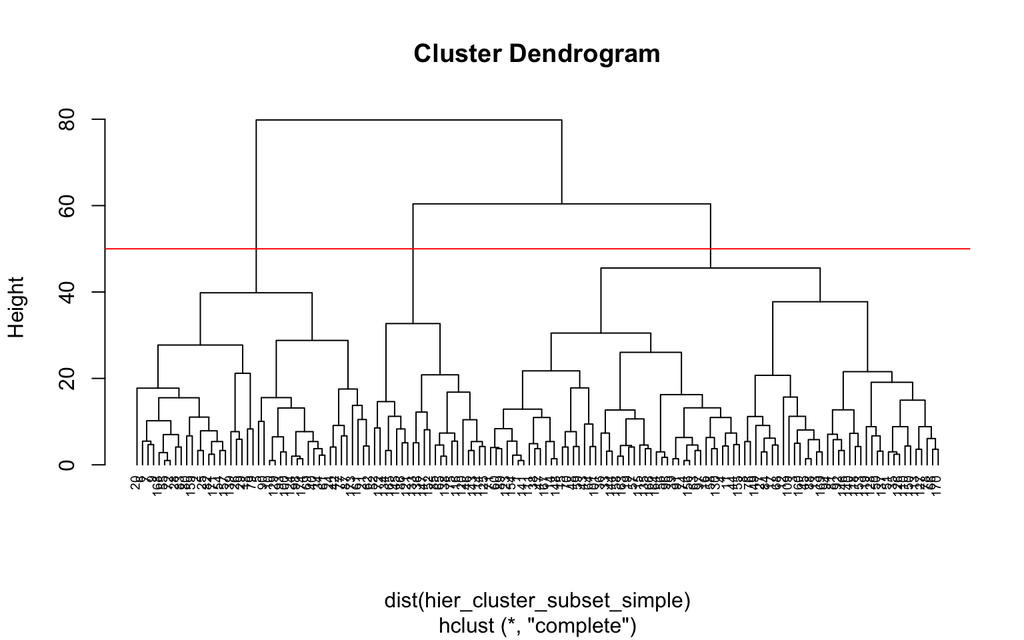

```r
hier_cluster_subset_simple <- adhd_data_3 %>% select(c('Age','ADHD.Total','MD.TOTAL'))
hier_cluster_complete_simple <- hclust(dist(hier_cluster_subset_simple),method="complete")
plot(hier_cluster_complete_simple, hang = -1, cex = 0.6)
abline(h = 50, col = "red")
```

Based on the above dendogram, we can see there are 3 distinct clusters. Again, we will cut our tree and view the output cluster assignments.

```r
num_cut = cutree(hier_cluster_complete_simple,3)
hier_cluster_subset_simple$cluster_pred <- num_cut
num_cut
```

```
##   1   2   3   4   5   6   7   8   9  10  11  12  13  14  15  16  17  18  19  20
##   1   2   1   1   2   2   2   1   2   2   1   1   1   1   1   1   1   2   1   2
##  21  24  25  26  27  28  29  33  34  35  36  38  39  40  42  43  44  45  46  47
##   2   2   2   2   1   2   2   1   2   1   1   1   1   2   2   1   1   1   3   1
##  48  50  51  52  54  55  56  57  58  59  60  61  62  63  64  65  66  68  69  70
##   1   1   1   3   2   2   1   1   1   1   1   2   2   1   1   3   1   1   2   1
##  71  72  74  75  76  77  78  79  80  81  82  83  84  85  86  87  88  89  90  91
##   1   2   1   3   1   2   1   2   2   1   2   2   1   3   3   2   1   1   2   1
##  92  93  94  96  97  98 100 101 109 110 111 113 114 115 116 118 119 120 121 123
##   1   2   1   1   1   2   2   1   1   1   1   1   3   1   3   1   1   3   3   1
## 124 125 126 127 128 129 130 133
##   2   3   1   1   1   2   1   3
##  [ reached getOption("max.print") -- omitted 38 entries ]
```

Here we can see that it appears that cluster 2 had a median and average age of 38. This cluster’s age fits right between cluster 1 & 3. Cluster 2 had the highest individual scores for reporting ADHD and reporting mood disorder. It would be interesting to see if there is any data to investigate if this age has any correlation with a mid-life crisis. Younger participants self reported the lower amount of ADHD and mood disorder.

```r
results_simple <- hier_cluster_subset_simple %>% dplyr::group_by(cluster_pred)
results_simple$Age <- as.numeric(as.character(results_simple$Age))
results_simple$ADHD.Total <- as.numeric(as.character(results_simple$ADHD.Total))
results_simple$MD.TOTAL <- as.numeric(as.character(results_simple$MD.TOTAL))
results_simple %>% dplyr::summarize(Avg_Age = mean(Age,na.rm=TRUE),
                                    Median_Age = median(Age,na.rm=TRUE),
                                    Avg_ADHD.Total = mean(ADHD.Total,na.rm=TRUE),
                                    Median_ADHD.Total = median(ADHD.Total,na.rm=TRUE),
                                    Avg_MD.TOTAL = mean(MD.TOTAL,na.rm=TRUE),
                                    Median_MD.TOTAL = median(MD.TOTAL,na.rm=TRUE))
```

```
## # A tibble: 3 × 7
##   cluster_pred Avg_Age Median_Age Avg_ADHD.Total Median_ADHD.Total Avg_MD.TOTAL
##          <int>   <dbl>      <dbl>          <dbl>             <dbl>        <dbl>
## 1            1    41.2         43          31.1                 31        10.3
## 2            2    38.3         38          54.5                 52        12.5
## 3            3    35.8         40           9.52                 9         6.29
## # … with 1 more variable: Median_MD.TOTAL <dbl>
```

## Xtreme Gradient Boosting (XGBoost)

Removing the lone record that Suicide is NA.

```r
# need to remove Suicide null
dim(adhd_data_3)
```

```
## [1] 146  54
```

```r
# skim(adhd_data_3)
adhd_data_4 <- adhd_data_3[complete.cases(adhd_data_3),]
dim(adhd_data_4)
```

```
## [1] 145  54
```

```r
# Dropping the 2 repeated columns
adhd_data_4 <- adhd_data_4[, -c(51:52)]
```

Splitting the train and test dataset

```r
set.seed(108)
sample_size <- floor(nrow(adhd_data_4)*0.8)
indices <- sample(1:nrow(adhd_data_4),sample_size)
data_train <- adhd_data_4[c(indices),]
data_test <- adhd_data_4[-c(indices),]
```

One-hot encoding of features, which is a requirement for XGBoost. At the end, you wanted to make sure the number of columns in data_train and data_test are the same.

```r
# do the 1-hot encoding for the data_train
Suicide <- data_train[, 49]
dummy <- dummyVars(" ~ . ", data = data_train [, -49] )
newdata <- data.frame(predict (dummy, newdata = data_train[, -49]))
data_train <- cbind (newdata, Suicide)
options(max.print="309")
colnames(data_train)
```

```
##   [1] "Age.18"               "Age.19"               "Age.20"
##   [4] "Age.21"               "Age.22"               "Age.23"
##   [7] "Age.24"               "Age.25"               "Age.26"
##  [10] "Age.27"               "Age.28"               "Age.29"
##  [13] "Age.30"               "Age.31"               "Age.32"
##  [16] "Age.33"               "Age.34"               "Age.35"
##  [19] "Age.36"               "Age.37"               "Age.38"
##  [22] "Age.39"               "Age.40"               "Age.41"
##  [25] "Age.42"               "Age.43"               "Age.44"
##  [28] "Age.45"               "Age.46"               "Age.47"
##  [31] "Age.48"               "Age.49"               "Age.50"
##  [34] "Age.51"               "Age.52"               "Age.53"
##  [37] "Age.54"               "Age.55"               "Age.56"
##  [40] "Age.57"               "Age.61"               "Age.69"
##  [43] "Sex.1"                "Sex.2"                "Race.1"
```

[output cut: 84 more lines]

```r
# repeat the same exercise for the data_test
Suicide1 <- data_test[, 49]
dummy1 <- dummyVars(" ~ . ", data = data_test [, -49] )
newdata1 <- data.frame(predict (dummy1, newdata = data_test[, -49]))
data_test <- cbind (newdata1, Suicide1)
colnames(data_test)
```

```
##   [1] "Age.18"               "Age.19"               "Age.20"
##   [4] "Age.21"               "Age.22"               "Age.23"
##   [7] "Age.24"               "Age.25"               "Age.26"
##  [10] "Age.27"               "Age.28"               "Age.29"
##  [13] "Age.30"               "Age.31"               "Age.32"
##  [16] "Age.33"               "Age.34"               "Age.35"
##  [19] "Age.36"               "Age.37"               "Age.38"
##  [22] "Age.39"               "Age.40"               "Age.41"
##  [25] "Age.42"               "Age.43"               "Age.44"
##  [28] "Age.45"               "Age.46"               "Age.47"
##  [31] "Age.48"               "Age.49"               "Age.50"
##  [34] "Age.51"               "Age.52"               "Age.53"
##  [37] "Age.54"               "Age.55"               "Age.56"
##  [40] "Age.57"               "Age.61"               "Age.69"
##  [43] "Sex.1"                "Sex.2"                "Race.1"
```

[output cut: 84 more lines]

```r
str(data_train)
```

```
## 'data.frame':    116 obs. of  295 variables:
##  $ Age.18              : num  0 0 0 0 0 0 0 0 0 0 ...
##  $ Age.19              : num  0 0 0 0 0 0 0 0 0 0 ...
##  $ Age.20              : num  0 0 0 0 0 0 0 0 0 0 ...
##  $ Age.21              : num  0 0 0 0 0 0 0 0 0 0 ...
##  $ Age.22              : num  0 0 0 0 0 0 0 0 0 0 ...
##  $ Age.23              : num  0 0 0 0 0 0 0 0 0 0 ...
##  $ Age.24              : num  0 0 0 0 0 0 0 0 0 0 ...
##  $ Age.25              : num  0 0 0 0 0 0 0 0 0 1 ...
##  $ Age.26              : num  0 0 0 0 0 0 0 0 0 0 ...
##  $ Age.27              : num  0 0 0 0 0 0 0 0 0 0 ...
##  $ Age.28              : num  0 0 0 0 0 0 0 0 0 0 ...
##  $ Age.29              : num  0 0 0 0 0 0 0 0 0 0 ...
##  $ Age.30              : num  0 0 0 0 0 0 0 0 0 0 ...
##  $ Age.31              : num  0 0 0 0 0 0 0 0 0 0 ...
```

[output cut: 86 more lines]

As you can tell below, the target variable in the data_train is unbalanced and is skewed toward 0 (68% 0s).

```r
table(data_train$Suicide)
```

```
##
##  0  1
## 79 37
```

```r
train_upsample <- upSample(x=data_train[, -295], y = data_train$Suicide)
# There is a new variable created called Class so that's why I can drop the Suicide column
table(train_upsample$Class)
```

```
##
##  0  1
## 79 79
```

Preparing the grid for XGBoost

```r
grid_tune <- expand.grid(
  nrounds = c(81), # of trees normal range is 1500 - 3000 depends on # of records
  max_depth = c(2, 4, 6),
  eta = c(0.01, 0.1, 0.3), # Learning rate
  gamma = 0,   # pruning normal range [0, 1]
  colsample_bytree = 1, # subsample ratio for columns for tree
  min_child_weight = 1, # the larger the more conservative the model is, can be used as a stop
  subsample = 1 # used to prevent overfitting by sampling x% training dataset
)
```

The following defines the trainControl and actually train the XGBoost

```r
trainControl <- trainControl (method = "cv",
                              number = 3,
                              verboseIter = T,
                              allowParallel = T
                             )

xgb_tune <- train(x = train_upsample[, -295],
                  y = train_upsample$Class,
                  trControl = trainControl,
                  tuneGrid = grid_tune,
                  method = "xgbTree",
                  verbose = T
                  )
```

```
## Fitting nrounds = 81, max_depth = 4, eta = 0.3, gamma = 0, colsample_bytree = 1, min_child_weight = 1, subsample = 1 on full training set
```

```r
# Best tune
xgb_tune$bestTune
```

```
##   nrounds max_depth eta gamma colsample_bytree min_child_weight subsample
## 8      81         4 0.3     0                1                1         1
```

```r
# Creating the best model
train_Control <- trainControl (method = "none",
                              verboseIter = T,
                              allowParallel = T
                             )

final_grid <- expand.grid(nrounds = xgb_tune$bestTune$nrounds,
                          eta = xgb_tune$bestTune$eta,
                          max_depth = xgb_tune$bestTune$max_depth,
                          gamma = xgb_tune$bestTune$gamma,
                          colsample_bytree = xgb_tune$bestTune$colsample_bytree,
                          min_child_weight = xgb_tune$bestTune$min_child_weight,
                          subsample = xgb_tune$bestTune$subsample
)

xgb_model <- train(x= train_upsample[, -295],
                   y = train_upsample$Class,
                   trControl = train_Control,
                   tuneGrid = final_grid,
                   method = "xgbTree",
                   verbose = F
)
```

```
## Fitting nrounds = 81, eta = 0.3, max_depth = 4, gamma = 0, colsample_bytree = 1, min_child_weight = 1, subsample = 1 on full training set
```

```r
# Creating prediction here
xgb.pred <- predict(xgb_model, data_test)
```

After creating xgb.pred, we run the Confusion Matrix to get the performance metrics.

```r
confusionMatrix(xgb.pred, data_test$Suicide)
```

```
## Confusion Matrix and Statistics
##
##           Reference
## Prediction  0  1
##          0 19  4
##          1  2  4
##
##                Accuracy : 0.7931
##                  95% CI : (0.6028, 0.9201)
##     No Information Rate : 0.7241
##     P-Value [Acc > NIR] : 0.2735
##
##                   Kappa : 0.4387
##
##  Mcnemar's Test P-Value : 0.6831
##
##             Sensitivity : 0.9048
##             Specificity : 0.5000
##          Pos Pred Value : 0.8261
##          Neg Pred Value : 0.6667
##              Prevalence : 0.7241
##          Detection Rate : 0.6552
##    Detection Prevalence : 0.7931
##       Balanced Accuracy : 0.7024
##
##        'Positive' Class : 0
##
```

Accuracy is 79.31% while Balanced Accuracy is only 70.24%

## Support Vector Machine (SVM)

SVM will help us decide on optimal decision boundary which can then help classify our labeled data. We’re going to model for the response variable suicide attempts with the adhd_data_3 dataset with both a radial and a linear kernel to try to find the decision boundary as we don’t know whether this is a non-linear problem or linear problem.

```r
adhd_data_4_matx = as.matrix(adhd_data_4)

df.corr.p = as.data.frame(rcorr(adhd_data_4_matx)$P)

# removing Suicide, and repeated columns
correlation_table <- cbind(rownames(df.corr.p), df.corr.p[, 49])[-c(49) , ]
correlation_table %>%
  kbl(caption = "Correlation with Suicide") %>%
  kable_material_dark()
```

Correlation with Suicide

| Age | 0.30027942497339 |
| --- | --- |
| Sex | 0.0471220935204864 |
| Race | 0.218309067324639 |
| ADHD.Q1 | 0.0117740269942401 |
| ADHD.Q2 | 0.11564807090846 |
| ADHD.Q3 | 0.259154266743925 |
| ADHD.Q4 | 0.112410726789768 |
| ADHD.Q5 | 0.216255750653531 |
| ADHD.Q6 | 0.483512910929568 |
| ADHD.Q7 | 0.048634884292714 |
| ADHD.Q8 | 0.151797641933531 |
| ADHD.Q9 | 0.322485825735442 |
| ADHD.Q10 | 0.291560841921094 |
| ADHD.Q11 | 0.515184561690949 |
| ADHD.Q12 | 0.395887015823113 |
| ADHD.Q13 | 0.584780116748058 |
| ADHD.Q14 | 0.249482531618938 |
| ADHD.Q15 | 0.112873665348362 |
| ADHD.Q16 | 0.201977696336559 |
| ADHD.Q17 | 0.872794003748846 |
| ADHD.Q18 | 0.546374843413306 |
| ADHD.Total | 0.102932484662113 |
| MD.Q1a | 0.0625907388295026 |
| MD.Q1b | 0.00317302701726341 |
| MD.Q1c | 0.960575599200187 |
| MD.Q1d | 0.0010368039318247 |
| MD.Q1e | 0.537896077431999 |
| MD.Q1f | 0.00712626183154863 |
| MD.Q1g | 0.000120152964638853 |
| MD.Q1h | 0.144730606824987 |
| MD.Q1i | 0.2592977551472 |
| MD.Q1j | 0.267581368524187 |
| MD.Q1k | 0.016734195148864 |
| MD.Q1L | 0.0156611407664968 |
| MD.Q1m | 0.403393642126824 |
| MD.Q2 | 0.000857782522594164 |
| MD.Q3 | 0.025029663425552 |
| MD.TOTAL | 0.000755726404960466 |
| Alcohol | 0.0138128897960139 |
| THC | 0.868985202967459 |
| Cocaine | 0.158974694425702 |
| Stimulants | 0.441880666140152 |
| Sedative.hypnotics | 0.0752635208018009 |
| Opioids | 0.016937963928505 |
| Court.order | 0.0805564613765424 |
| Education | 0.230822596373245 |
| Hx.of.Violence | 0.149606337250033 |
| Disorderly.Conduct | 0.704780193506212 |
| Abuse | 0.000396677403584178 |
| NonSubstDx | 0.693218272432247 |
| SubstDx | 0.0468228684891696 |

- Age
- ADHD.Q6
- ADHD.Q9
- ADHD.Q11
- ADHD.Q12
- ADHD.Q13
- ADHD.Q17
- ADHD.Q18
- MD.Q1c
- MD.Q1e
- MD.Q1m
- THC
- Stimulants
- Disorderly.Conduct
- NonSubstDx

```r
svm_selected <- as.data.frame(cbind(rownames(df.corr.p[df.corr.p[, 49] >= .5,]), df.corr.p[df.corr.p[, 49]>= .5, 49 ]))
svm_selected <-  svm_selected[complete.cases(svm_selected), ]
rownames(svm_selected) <- seq(length=nrow(svm_selected))
svm_selected
```

```
##                   V1                V2
## 1           ADHD.Q11 0.515184561690949
## 2           ADHD.Q13 0.584780116748058
## 3           ADHD.Q17 0.872794003748846
## 4           ADHD.Q18 0.546374843413306
## 5             MD.Q1c 0.960575599200187
## 6             MD.Q1e 0.537896077431999
## 7                THC 0.868985202967459
## 8 Disorderly.Conduct 0.704780193506212
## 9         NonSubstDx 0.693218272432247
```

```r
adhd <- adhd_data_4 %>% select(c(svm_selected$V1, 'Suicide' ))
```

```r
set.seed(45)
indexes = createDataPartition(adhd$Suicide, p = .85, list = F) # results not in a List
train = adhd[indexes, ]
test = adhd[-indexes, ]

wts <- 100 / table(test$Suicide)
wts
```

```
##
##         0         1
##  6.666667 16.666667
```

```r
radial_svm = svm(Suicide~., data=train, class.weights = wts, C = 13)
print(radial_svm)
```

```
##
## Call:
## svm(formula = Suicide ~ ., data = train, class.weights = wts, C = 13)
##
##
## Parameters:
##    SVM-Type:  C-classification
##  SVM-Kernel:  radial
##        cost:  1
##
## Number of Support Vectors:  112
```

```r
test$pred = predict(radial_svm, test)

confusionMatrix(test$pred, test$Suicide)
```

```
## Confusion Matrix and Statistics
##
##           Reference
## Prediction  0  1
##          0 11  5
##          1  4  1
##
##                Accuracy : 0.5714
##                  95% CI : (0.3402, 0.7818)
##     No Information Rate : 0.7143
##     P-Value [Acc > NIR] : 0.9501
##
##                   Kappa : -0.1053
##
##  Mcnemar's Test P-Value : 1.0000
##
##             Sensitivity : 0.7333
##             Specificity : 0.1667
##          Pos Pred Value : 0.6875
##          Neg Pred Value : 0.2000
##              Prevalence : 0.7143
##          Detection Rate : 0.5238
##    Detection Prevalence : 0.7619
##       Balanced Accuracy : 0.4500
##
##        'Positive' Class : 0
##
```

```r
linear_svm = svm(factor(Suicide)~., data=train, kernel = "linear", type = 'C-classification', cost = 10, scale = F, class.weights = wts)
print(linear_svm)
```

```
##
## Call:
## svm(formula = factor(Suicide) ~ ., data = train, kernel = "linear",
##     type = "C-classification", cost = 10, class.weights = wts, scale = F)
##
##
## Parameters:
##    SVM-Type:  C-classification
##  SVM-Kernel:  linear
##        cost:  10
##
## Number of Support Vectors:  98
```

```r
test$pred = predict(linear_svm, test)

confusionMatrix(test$pred, test$Suicide)
```

```
## Confusion Matrix and Statistics
##
##           Reference
## Prediction  0  1
##          0 12  4
##          1  3  2
##
##                Accuracy : 0.6667
##                  95% CI : (0.4303, 0.8541)
##     No Information Rate : 0.7143
##     P-Value [Acc > NIR] : 0.7705
##
##                   Kappa : 0.1404
##
##  Mcnemar's Test P-Value : 1.0000
##
##             Sensitivity : 0.8000
##             Specificity : 0.3333
##          Pos Pred Value : 0.7500
##          Neg Pred Value : 0.4000
##              Prevalence : 0.7143
##          Detection Rate : 0.5714
##    Detection Prevalence : 0.7619
##       Balanced Accuracy : 0.5667
##
##        'Positive' Class : 0
##
```

Linear SVM performs better with a higher Balanced Accuracy. Thus, we will focus on improving the linear SVM.

We used correlation coefficients to select the model variables before. Let’s take a different approach and examine some charts of the predictor variables and target variable using the ggpairs function.

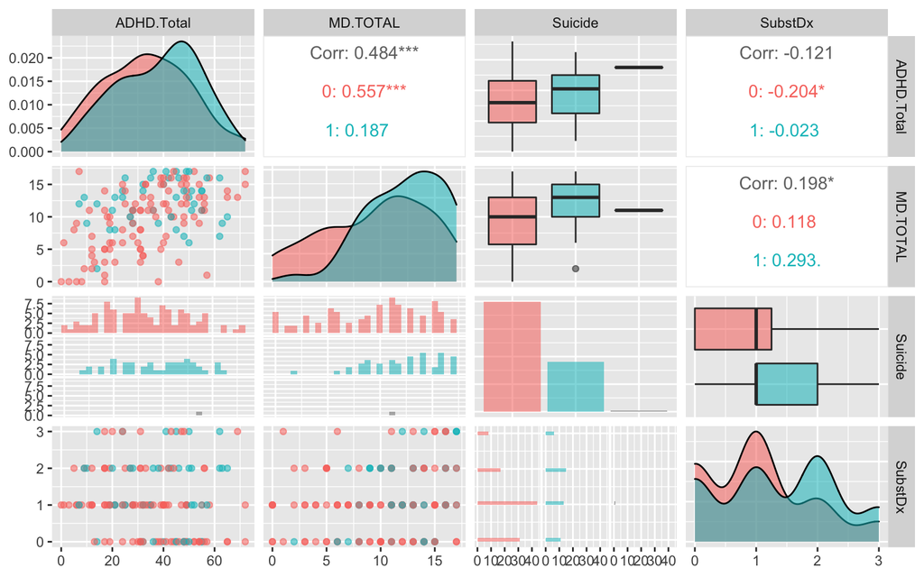

```r
#remove individual ADHD and MD question columns, keeping only the total columns
adhd_data_31<- adhd_data_3[, -c(4:21, 23:37)]
#identify all factor columns
x <- sapply(adhd_data_31, is.factor)
#convert all factor columns to numeric
adhd_data_31[ , x] <- as.data.frame(apply(adhd_data_31[ , x], 2, as.numeric))
adhd_data_31$Suicide <- as.factor(adhd_data_3$Suicide)

ggpairs(adhd_data_31, columns = c(4,5,16,21), aes(colour = Suicide, alpha = 0.4))
```

From the plots above, particularly the box plots, it is evident that MD.TOTAL and SubstDx separate our target variable pretty well. However, note that there is some overlap between the target variable classes. We will use these two variables in our final model.

```r
set.seed(125)
adhd_data_3_model <- subset(adhd_data_3, select=c(SubstDx, MD.TOTAL, Suicide))
indexes = createDataPartition(adhd_data_3_model$Suicide, p = .85, list = F) # results not in a List
train = adhd_data_3_model[indexes, ]
test = adhd_data_3_model[-indexes, ]

linear_svm_final = svm(factor(Suicide)~., data=train, kernel = "linear", type = 'C-classification', cost = 10, scale = F, class.weights = wts)
print(linear_svm_final)
```

```
##
## Call:
## svm(formula = factor(Suicide) ~ ., data = train, kernel = "linear",
##     type = "C-classification", cost = 10, class.weights = wts, scale = F)
##
##
## Parameters:
##    SVM-Type:  C-classification
##  SVM-Kernel:  linear
##        cost:  10
##
## Number of Support Vectors:  93
```

```r
test$pred = predict(linear_svm_final, test)

confusionMatrix(test$pred, test$Suicide)
```

```
## Confusion Matrix and Statistics
##
##           Reference
## Prediction 0 1
##          0 7 4
##          1 8 2
##
##                Accuracy : 0.4286
##                  95% CI : (0.2182, 0.6598)
##     No Information Rate : 0.7143
##     P-Value [Acc > NIR] : 0.9985
##
##                   Kappa : -0.1667
##
##  Mcnemar's Test P-Value : 0.3865
##
##             Sensitivity : 0.4667
##             Specificity : 0.3333
##          Pos Pred Value : 0.6364
##          Neg Pred Value : 0.2000
##              Prevalence : 0.7143
##          Detection Rate : 0.3333
##    Detection Prevalence : 0.5238
##       Balanced Accuracy : 0.4000
##
##        'Positive' Class : 0
##
```

```r
# set.seed(688)
# # recoding Loan_Status back to categorical variable
# loan_knn2$Loan_Status <- as.factor(loan_knn2$Loan_Status)
# str(loan_knn2)
#
#
# # Data Partitioning
# trainIndex <- createDataPartition(loan_knn2$Loan_Status, p = .8, list = FALSE, times = 1)
# knn_train <- loan_knn2[trainIndex,]
# knn_test  <- loan_knn2[-trainIndex,]
#
#
#
# str(knn_train)
```

```r
# trControl <- trainControl(method  = "repeatedcv",
#                           repeats  = 11)
# knn.fit <- train(Loan_Status ~ .,
#              method     = "knn",
#              tuneGrid   = expand.grid(k = 1:10),
#              trControl  = trControl,
#              preProcess = c("center","scale"),
#              data       = knn_train
#              )
```

```r
# knn_pred <- predict(knn.fit, newdata = knn_test)
# # options('max.print' = 100)
# # getOption("max.print")
# confusionMatrix(knn_pred, knn_test$Loan_Status)
```